# Praca domowa 2

Nina Onyszczuk

## Dane

Dane wykorzystane w Pracy domowej 2 dotyczą wyników egzaminów z 3 umiejętności: czytania, pisania i operacji matematycznych. Dodatkowo dostępne są podstawowe informacje o studentach i ich rodzicach. Opis wszystkich kolumn znajduje się również w pliku `README.md`.

| Zmienna | Opis |
| --- | --- |
| **gender** | płeć |
| **race.ethnicity** | pochodzenie etniczne |
| **parental.level.of.education** | wykształcenie rodziców |
| **lunch** | jaki obiad jedli uczniowie w dniu egzaminu |
| **test.preparation.course** | czy uczeń odbył kurs przygotowujący |
| **math.score** | wynik egzaminu z matematyki |
| **reading.score** | wynik egzaminu z czytania |
| **writing.score** | wynik egzaminu z pisania |

## Zadanie 1

Jak wyglądają rozkłady wyników uczniów z trzech przedmiotów (matematyka, czytanie, pisanie)?

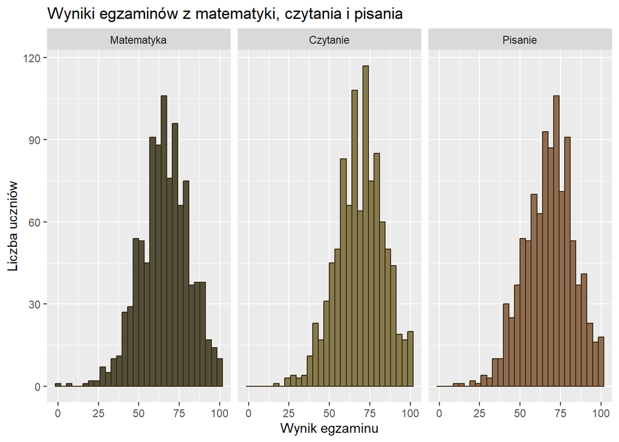

```r
# Tu umieść kod do wygenerowania odpowiedzi do zadania.

df %>%
  tidyr::pivot_longer(cols = ends_with('score'), names_to = 'category', names_pattern = '(.*).score', values_to = 'score') %>%
  ggplot(aes(x = score, fill = category))+
  geom_histogram(color = '#37250b')+
  labs(title = 'Wyniki egzaminów z matematyki, czytania i pisania',
       x = 'Wynik egzaminu',
       y = 'Liczba uczniów')+
  theme(legend.position = 'none')+
  scale_fill_manual(values = c('#52503a', '#857b4d', '#8f6c51'))+
  facet_wrap(~category,
             labeller = labeller(category = c('math' = 'Matematyka', 'reading' = 'Czytanie', 'writing' = 'Pisanie')))
```

**Komentarz: Rozkłady wyników egzaminów z poszczególnych przedmiotów są podobne do siebie wzajemnie.**

## Zadanie 2

Czy istnieje zauważalna różnica w wynikach między uczniami i uczennicami?

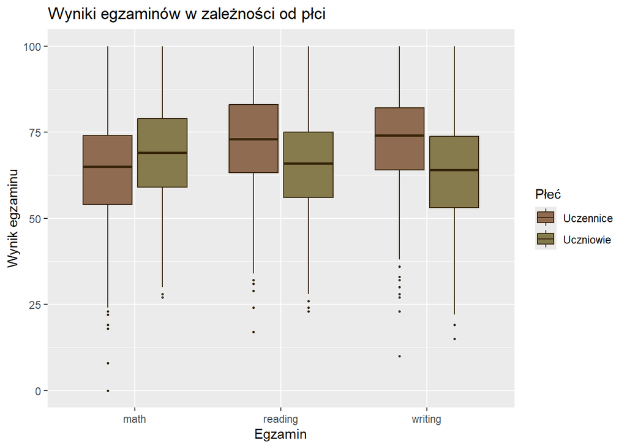

```r
# Tu umieść kod do wygenerowania odpowiedzi do zadania.

df %>%
  tidyr::pivot_longer(cols = ends_with('score'), names_to = 'category', names_pattern = '(.*).score', values_to = 'score') %>%
  ggplot(aes(x = category, y = score, fill = gender))+
  geom_boxplot(color = '#37250b', outlier.size = 0.5)+
  labs(title = 'Wyniki egzaminów w zależności od płci',
       x = 'Egzamin',
       y = 'Wynik egzaminu',
       fill = 'Płeć')+
  scale_fill_manual(labels = c('Uczennice', 'Uczniowie'),values = c('#8f6c51', '#857b4d'))
```

**Komentarz: Istnieje zauważalna różnica w wynikach między uczniami a uczennicami. Uczniowie osiągneli średnio wyższe wyniki z egzaminu z matematyki, gdzie uczennice osiągnęły średnio wyższe wyniki z egzaminów z czytania i pisania.**

## Zadanie 3

Czy uczniowie, którzy ukończyli kurs przygotowawczy, osiągają lepsze wyniki niż pozostali?

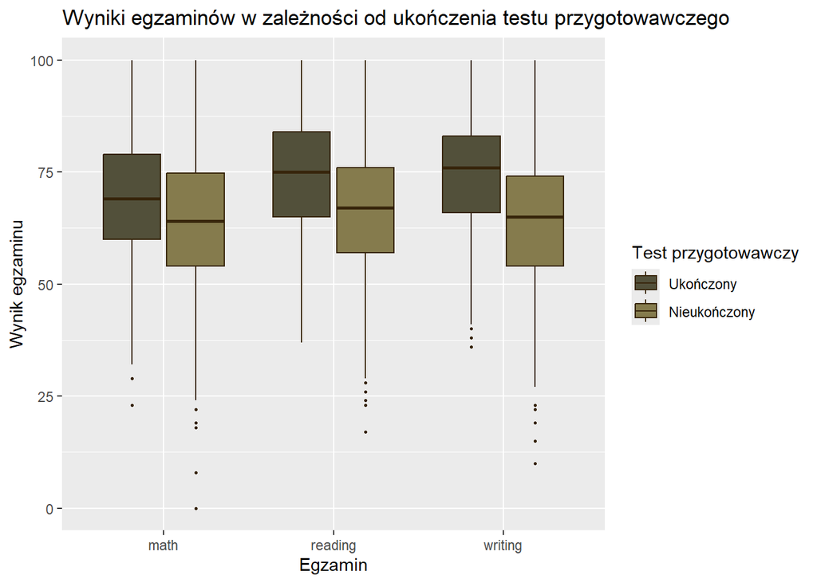

```r
# Tu umieść kod do wygenerowania odpowiedzi do zadania.

df %>%
  tidyr::pivot_longer(cols = ends_with('score'), names_to = 'category', names_pattern = '(.*).score', values_to = 'score') %>%
  ggplot(aes(x = category, y = score, fill = test.preparation.course))+
  geom_boxplot(color = '#37250b', outlier.size = 0.5)+
  labs(title = 'Wyniki egzaminów w zależności od ukończenia testu przygotowawczego',
       x = 'Egzamin',
       y = 'Wynik egzaminu',
       fill = 'Test przygotowawczy')+
  scale_fill_manual(labels = c('Ukończony', 'Nieukończony'), values = c('#52503a', '#857b4d'))
```

**Komentarz: Uczniowie, którzy ukończyli test przygotowawczy osiągają średnio wyższe wyniki niż uczniowie, którzy tego testu nie ukończyli.**

## Zadanie 4

Jaki jest związek między poziomem wykształcenia rodziców a średnimi wynikami uczniów?

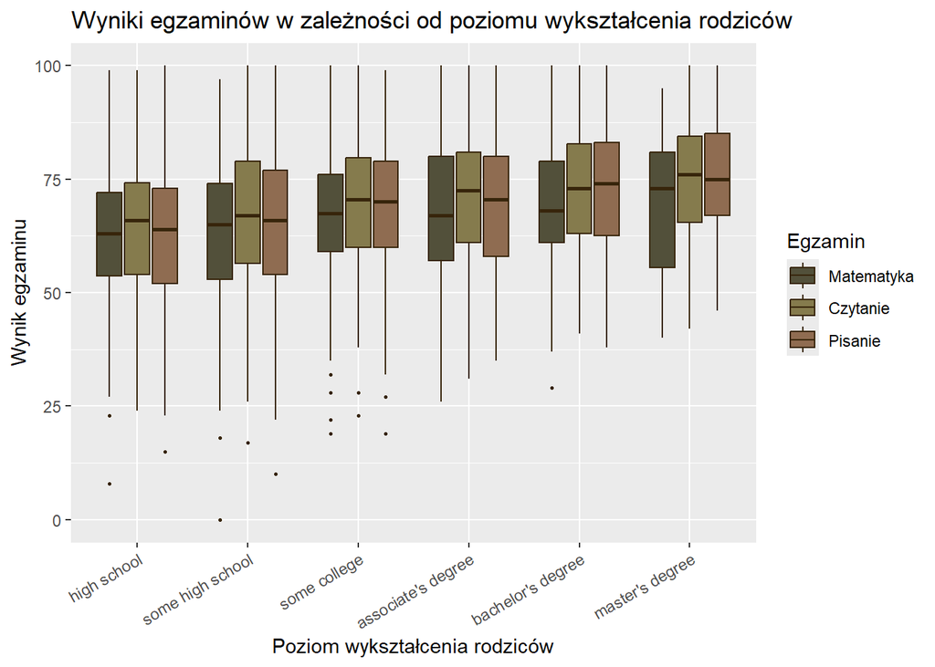

```r
# Tu umieść kod do wygenerowania odpowiedzi do zadania.

df %>%
  tidyr::pivot_longer(cols = ends_with('score'), names_to = 'category', names_pattern = '(.*).score', values_to = 'score') %>%
  ggplot(aes(x = forcats::fct_reorder(parental.level.of.education, score), y = score, fill = category))+
  geom_boxplot(color = '#37250b', outlier.size = 0.5)+
  labs(title = 'Wyniki egzaminów w zależności od poziomu wykształcenia rodziców',
       x = 'Poziom wykształcenia rodziców',
       y = 'Wynik egzaminu',
       fill = 'Egzamin')+
  scale_fill_manual(labels =c('Matematyka', 'Czytanie', 'Pisanie'),
                    values = c('#52503a', '#857b4d', '#8f6c51'))+
  scale_x_discrete(guide = guide_axis(angle = 30))
```

**Komentarz: Uczniowie, których rodzice posiadają wyższy poziom wykształcenia, osiągają średnio wyższe wyniki z egzaminów.**

## Zadanie 5

Czy płeć i wykształcenie rodzica wpływa na wynik z matematyki?

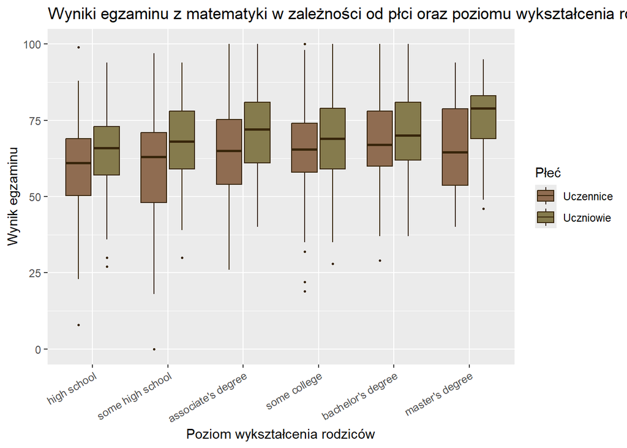

```r
# Tu umieść kod do wygenerowania odpowiedzi do zadania.

df %>%
  ggplot(aes(x = forcats::fct_reorder(parental.level.of.education, math.score), y = math.score, fill = gender))+
  geom_boxplot(color = '#37250b', outlier.size = 0.5)+
  labs(title = 'Wyniki egzaminu z matematyki w zależności od płci oraz poziomu wykształcenia rodziców',
       x = 'Poziom wykształcenia rodziców',
       y = 'Wynik egzaminu',
       fill = 'Płeć')+
  scale_fill_manual(labels = c('Uczennice', 'Uczniowie'),values = c('#8f6c51', '#857b4d'))+
  scale_x_discrete(guide = guide_axis(angle = 30))
```

**Komentarz: Zarówno płeć zdającego jak i wykształcenie rodziców wpływają na wyniki egzaminu z matematyki. Uczniowie osiągają wyższe wyniki niż uczennice oraz uczniowie, których rodzice posiadają wyższy poziom wykształcenia, osiągają średnio lepsze wyniki.**

## Zadanie 6

Czy istnieje zależność między wynikami z matematyki a wynikami z czytania lub pisania?

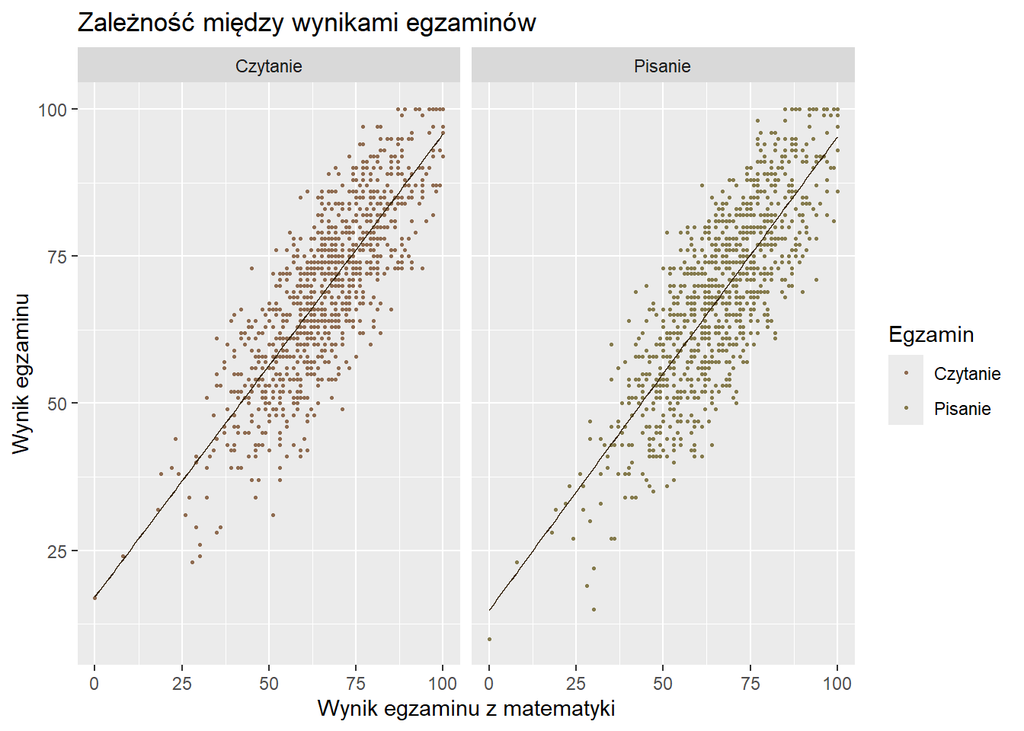

```r
# Tu umieść kod do wygenerowania odpowiedzi do zadania.

df %>%
  tidyr::pivot_longer(cols = c(reading.score, writing.score), names_to = 'category', names_pattern = '(.*).score', values_to = 'score') %>%
  ggplot(aes(x = math.score, y = score, color = category))+
  geom_point(size = 0.5)+
  geom_smooth(method = lm, color = '#37250b', se = FALSE, linewidth = 0.5)+
  labs(title = 'Zależność między wynikami egzaminów',
       x = 'Wynik egzaminu z matematyki',
       y = 'Wynik egzaminu',
       color = 'Egzamin')+
  scale_color_manual(labels = c('Czytanie', 'Pisanie'),values = c('#8f6c51', '#857b4d'))+
  facet_wrap(~category,
             labeller = labeller(category = c('reading' = 'Czytanie', 'writing' = 'Pisanie')))
```

**Komentarz: Istnieje zależność między wynikami egzaminu z matematyki a wynikami egzaminu z czytania i pisania. Im wyższy wynik z egzaminu z matematyki, tym wyższe wyniki z egzaminu z czytania i pisania.**